# Road accidents in New York

### Monthly Accidents and Rainfall

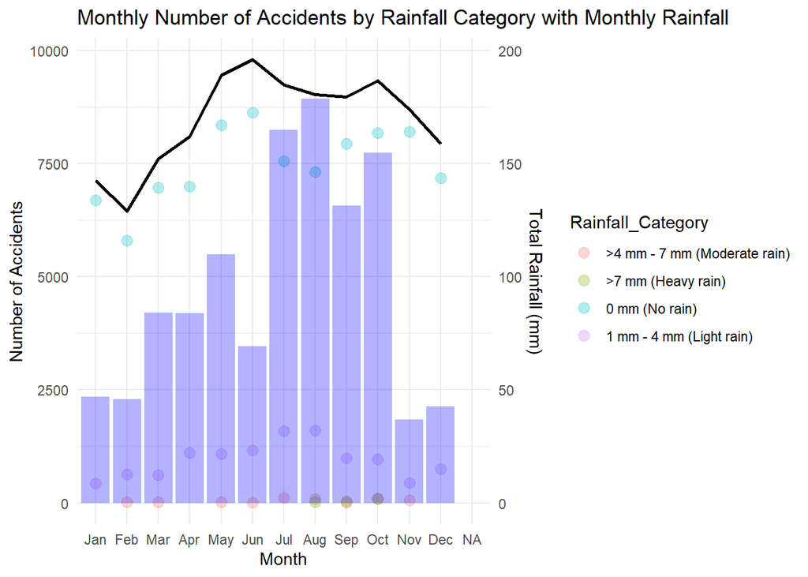

This graph shows the monthly number of accidents in New York in 2021, categorized by rainfall intensity. The black line represents the total number of accidents per month, while the blue bars represent the total rainfall per month on a secondary y-axis. The dots represent the number of accidents in each rainfall category.

At the same time, the majority of accidents occur in no rain conditions, which could be due simply to the fact that most of the time there is no rain in New York. Hence, ithout the a total amount of vehicles on the road, it is difficult to draw conclusions from this data alone.

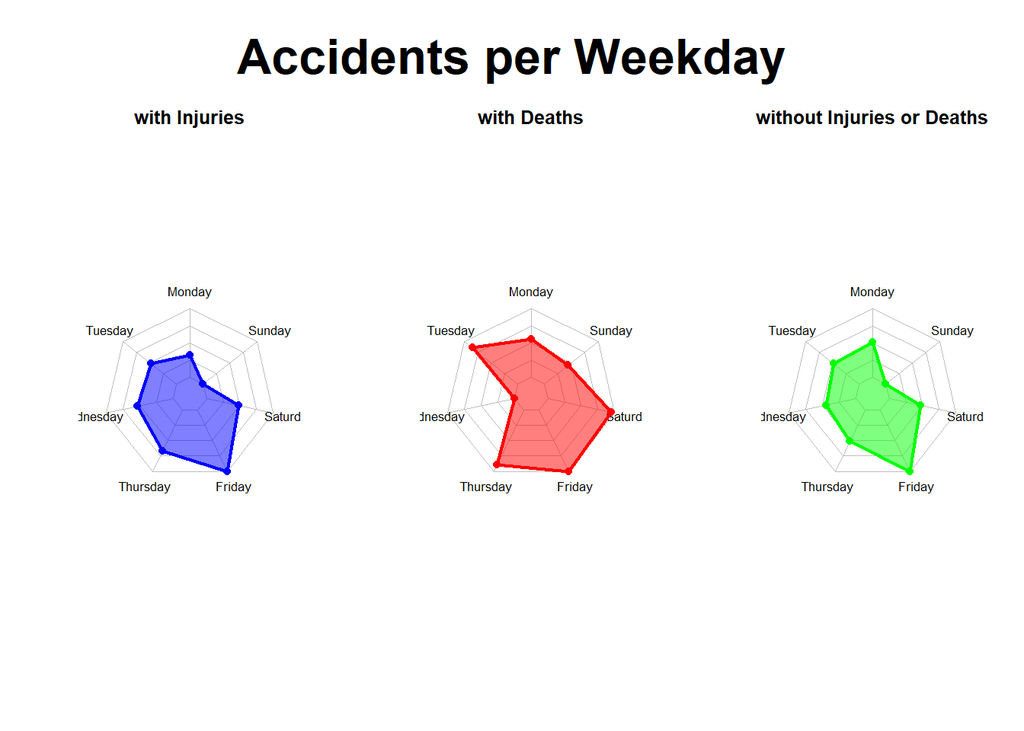

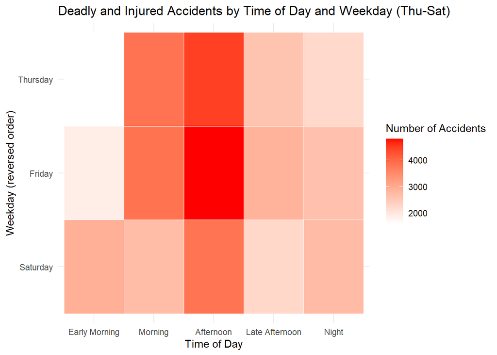

[figure not shown]

## Chapter of Choice (Esquisse (Web Server App))

### If you like Tableau, you will love Esquisse

Esquisse is a package that allows you to create interactive plots and dashboards in R. It is similar to Tableau in that it provides a user-friendly interface for creating visualizations without writing code.

To use Esquisse, you need to install the package and then load it in your R script. After loading the package, you can launch the web app by calling the `esquisser()` function with your data as an argument. That will open a web browser with the Esquisse interface, where you can create plots interactively by dragging and dropping variables. Esquisse works with the `plotly` package to create interactive plots.

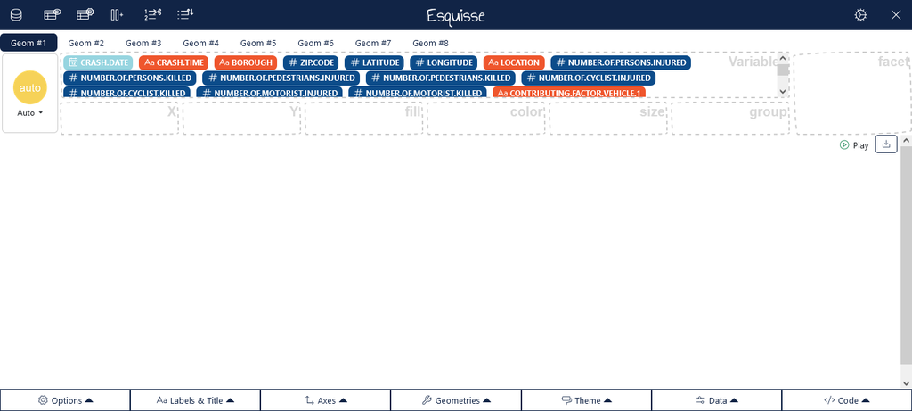

Esquisse

At the botom left of the pane, in the options tab, you can select to make the plots with `plotly` to make them interactive. Once active, you can hover over the plots to see the data points and values or click on the legend to filter the data.

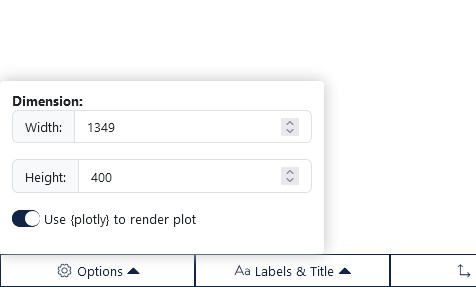

Esquisse Options